# Exercise 08

Author

Gianfranco Botta (GianfrancoBotta)

Published

November 14, 2023

## Import libraries

```r
library("ggplot2")
library("edgeR")
library("limma")
library("pasilla")
library("DEXSeq")
```

## Set seed

```r
set.seed(1234)
```

## Question 1

*Simulate data from the sine curve (from 0 to 2pi) with Gaussian noise added (as shown in the lecture). Try and “normalize” the sine curve data. That is, subtract the trend of the data, such that if the normalization succeeds, you are left with normally distributed data centred around zero. After this: i) make a plot of the normalized data; ii) make a plot of the difference between the truth (sine curve) and the loess/lowess estimate; iii) create a quantile-quantile (against Gaussian) plot of the normalized data. Comment on the results. Did your normalization work? Does it look (sufficiently) Gaussian? You may need to play with parameters to get a “good” lowess/loess estimate in the first place.*

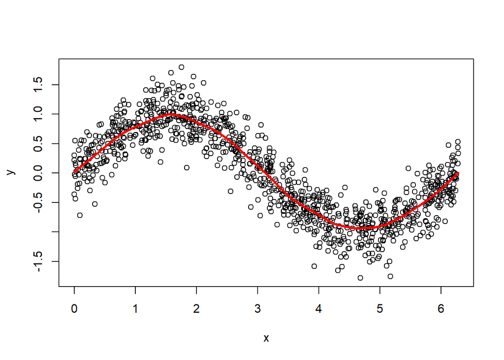

```r
x <- sort(runif(1000, 0, 2*pi))
y <- sin(x) + rnorm(1000, sd = .3)
lowess_data <- lowess(y~x, f=1/7)

plot(x,y)
lines(lowess_data, col="red", lwd=3)
```

After having found the best lowess to effectively normalize the sine curve data, we plot the density of the normalized data. To know how to correctly smooth the data, we have to know that the parameter f gives the proportion of points in the plot which influence the smooth at each value.

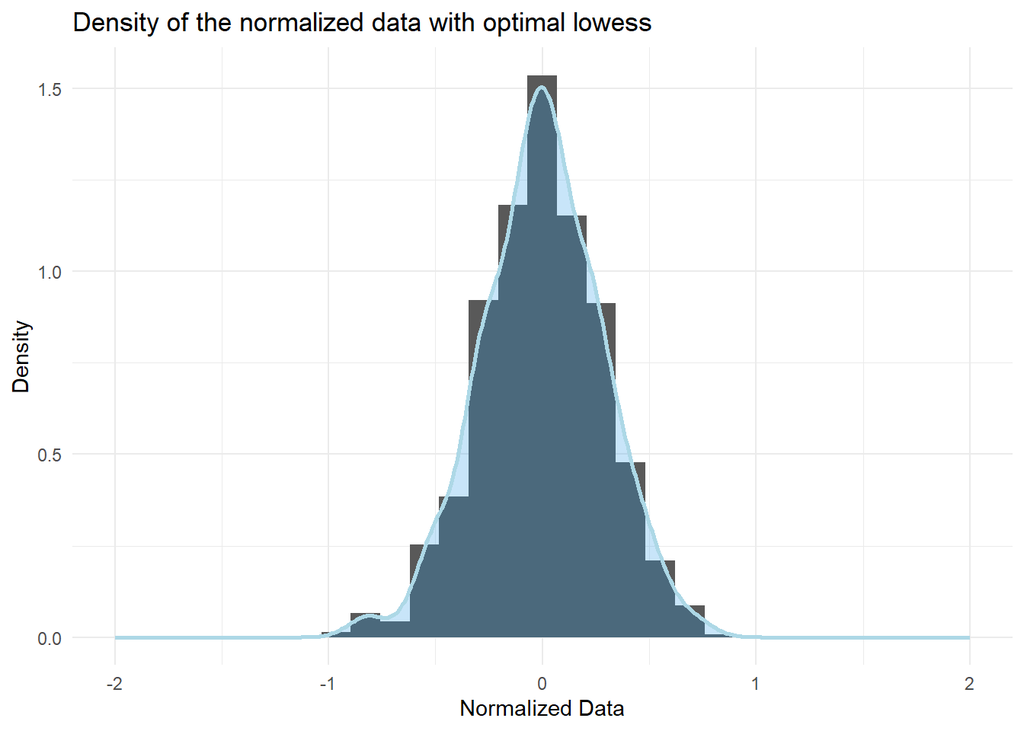

```r
norm_data <- y-lowess_data$y
norm_df <- data.frame(Data = norm_data)

ggplot(norm_df, aes(x = Data)) +
  geom_histogram(aes(y = after_stat(density))) +
  geom_density(lwd = 1, colour = "lightblue",
               fill = 4, alpha = 0.25) +
  xlim(c(-2,2)) +
  theme_minimal() +
  labs(x = "Normalized Data",
       y = "Density") +
  ggtitle("Density of the normalized data with optimal lowess")
```

Now we can plot the difference between the truth (sine curve) and the loess/lowess estimate.

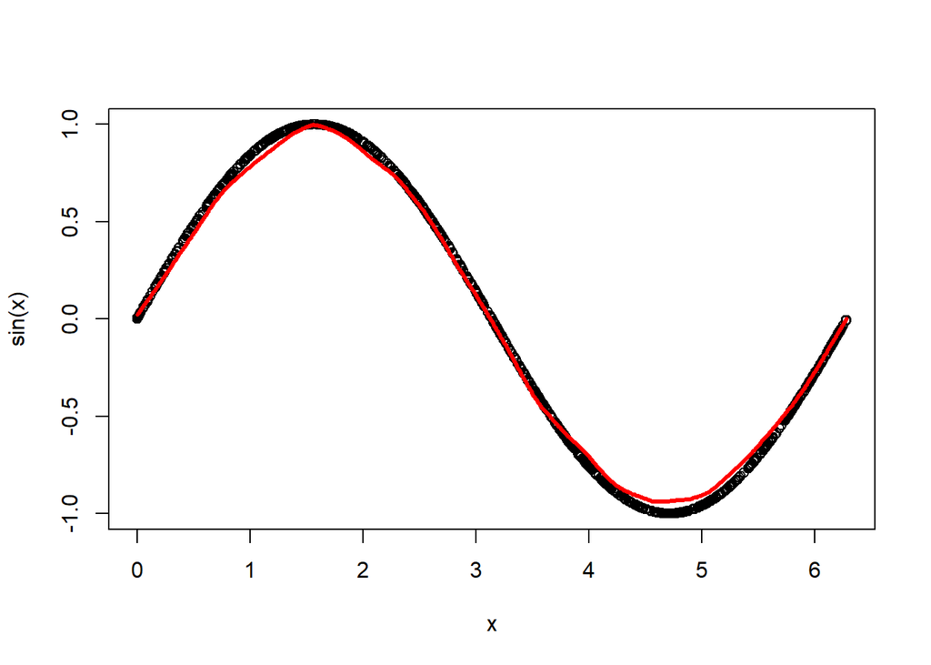

```r
plot(x, sin(x))
lines(lowess_data, col="red", lwd=3)
```

Finally, we create a quantile-quantile (against Gaussian) plot of the normalized data.

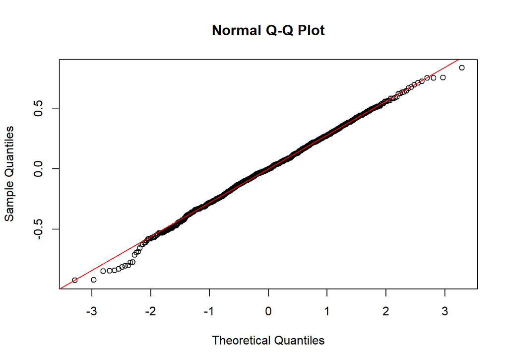

```r
qqnorm(norm_data)
qqline(norm_data, col="red")
```

Our normalization works, because the qq-plot fits very well the qq-line.

## Question 2

*Take the data from Exercise 7 and produce an MDS plot again, but this time colour the points according to the libtype covariate in the samples table: SE = single end, PE = paired end (i.e., a technical detail of the library construction); perhaps also label the points on the MDS plot using the shortname column to make them easy to distinguish. Comment on the relative positions of the samples.*

```r
dir_pasilla <- "C:/Users/gianf/OneDrive/Documenti/DOCUMENTS_ETH/1 YEAR/1 SEMESTER/SAHTGTD/EXERCISES/pasilla_data"
setwd(dir_pasilla)
file_path <- paste0(dir_pasilla,"/samples.txt")
(samples <- read.table(file_path, header=TRUE,
                      row.names=5, stringsAsFactors=FALSE))
```

```
                  rep condition libtype shortname           countfile
CG8144_RNAi-1.bam  T1         T      SE     T1.SE CG8144_RNAi-1.count
CG8144_RNAi-3.bam  T3         T      PE     T3.PE CG8144_RNAi-3.count
CG8144_RNAi-4.bam  T4         T      PE     T4.PE CG8144_RNAi-4.count
Untreated-1.bam    C1         C      SE     C1.SE   Untreated-1.count
Untreated-6.bam    C6         C      SE     C6.SE   Untreated-6.count
Untreated-3.bam    C3         C      PE     C3.PE   Untreated-3.count
Untreated-4.bam    C4         C      PE     C4.PE   Untreated-4.count
```

```r
counts <- readDGE(samples$countfile)$counts
head(counts)
```

```
             Samples
Tags          CG8144_RNAi-1 CG8144_RNAi-3 CG8144_RNAi-4 Untreated-1 Untreated-6
  FBgn0000008           115            87            68         138          83
  FBgn0000014             0             8             2           1           1
  FBgn0000015             5             2             0           2           0
  FBgn0000017          4579          3074          3313        7152        4099
  FBgn0000018           531           288           307         617         486
  FBgn0000022             0             0             0           1           0
             Samples
Tags          Untreated-3 Untreated-4
  FBgn0000008          75          71
  FBgn0000014           3           4
  FBgn0000015           0           2
  FBgn0000017        3547        3139
  FBgn0000018         240         307
  FBgn0000022           0           0
```

```r
grp_l <- samples$libtype
group_l <- factor(grp_l)
y_l <- DGEList(counts=counts,group=group_l)
```

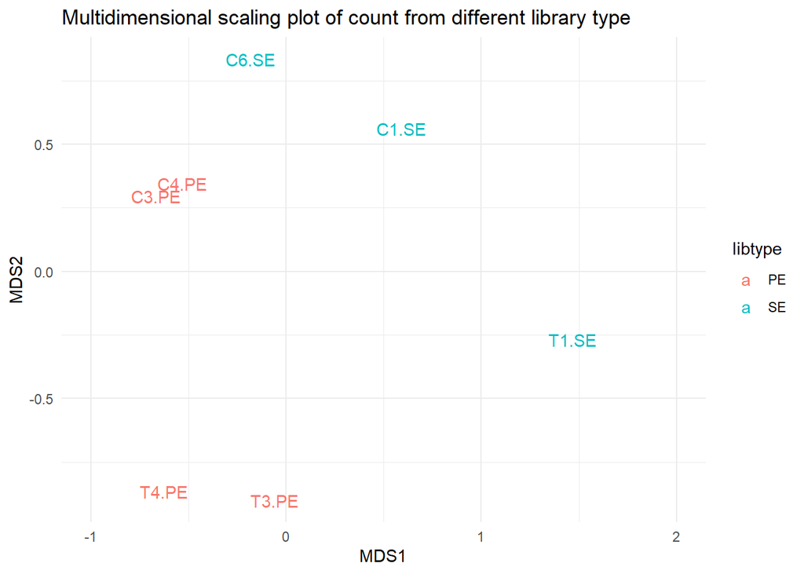

```r
mds <- plotMDS(y_l, col = as.numeric(group_l), plot = FALSE)

df <- data.frame(MDS1 = mds$x, MDS2 = mds$y,
                 libtype = y_l$samples$group,
                 names = samples$shortname)

ggplot(df, aes(x = MDS1, y = MDS2, colour=libtype)) +
  geom_text(aes(label = names)) +
  xlim(-1,2) +
  theme_minimal() +
  ggtitle("Multidimensional scaling plot of count from different library type")
```

## Question 3

*Put a factor variable for the libtype covariate in the design matrix and redo the edgeR or limma differential expression analysis from Exercise 7 (i.e., include also the biological factor of interest, knockout state, in the design matrix). This now represents modeling where we are still interested in the knockout state, but the model now adjusts for the effects of libtype (with some assumptions). Compare the set of genes called DE from Exercise 7 (i.e., without accounting for the covariate) to this new analysis. Identify and plot (normalized) expression levels of a gene that is affected solely by library type (i.e., and not by knockout state).*

We can build the new design matrix based both on condition and library type to run the edgeR pipeline. However, to compare the set of genes called DE with and without accounting for the covariate libtype, we have first to reproduce the analysis and result of exercise 7.

```r
grp <- gsub("\\-.[0-9]*","",colnames(counts))
group <- factor(grp)
y_c <- DGEList(counts=counts,group=group)
y_c <- calcNormFactors(y_c)
design_c <- model.matrix(~ group)

y_c <- estimateDisp(y_c,design_c)
fit_c <- glmFit(y_c,design_c)
lrt_c <- glmLRT(fit_c,coef=2)
```

And now we can repeat the edgeR pipeline accounting both for condition and library type.

```r
libtype <- factor(samples$libtype)
y <- DGEList(counts=counts,group=group)
y <- calcNormFactors(y)
design <- model.matrix(~ group + libtype)
y <- estimateDisp(y,design)
fit <- glmFit(y,design)
lrt <- glmLRT(fit,coef=3)
```

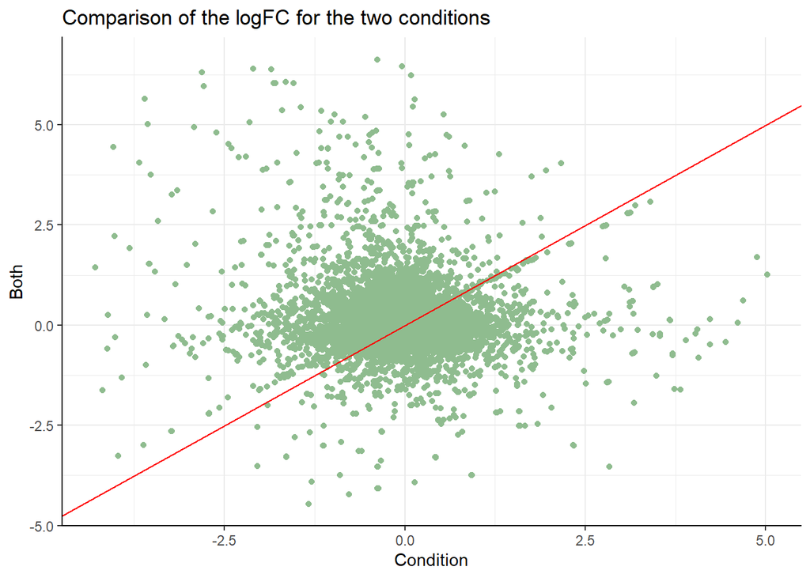

```r
logFC <- data.frame(Condition = lrt_c$table$logFC,
                    Both = lrt$table$logFC)

ggplot(logFC, aes(x = Condition, y = Both)) +
  geom_point(color = "darkseagreen") +
  theme_bw() +
    theme(
      panel.border = element_blank(),
      axis.line = element_line(color = "black", linewidth = 0.5, lineend = "square")
    ) +
  geom_abline(intercept = 0, slope = 1, color = "red") +
  ggtitle("Comparison of the logFC for the two conditions")
```

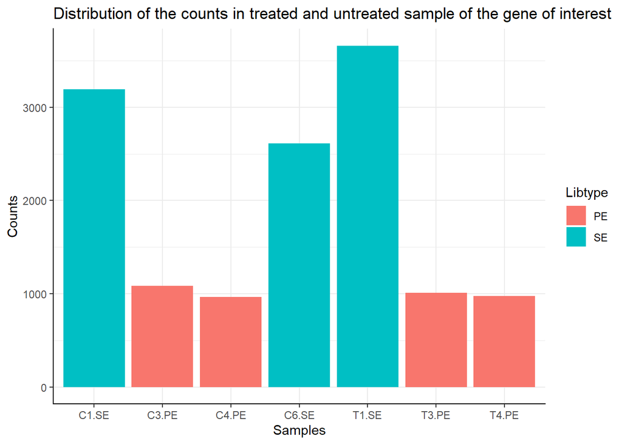

```r
gene_name <- "FBgn0002566"
gene_counts <- data.frame(Counts = y$counts[gene_name, ],
                          Indices = samples$shortname,
                          Libtype = samples$libtype)

ggplot(data = gene_counts, aes(x = Indices, y = Counts, fill = Libtype)) +
  geom_histogram(stat = "identity") +
  theme_bw() +
  theme(
    panel.border = element_blank(),
    axis.line = element_line(color = "black", linewidth = 0.5, lineend = "square")
  ) +
  labs(x = "Samples",
       y = "Counts") +
  ggtitle("Distribution of the counts in treated and untreated sample of the gene of interest")
```

We see that in the gene plotted, the counts depend solely on the libtype and not on the condition.

## Question 4

*Fix the above code to run a standard DEXSeq analysis and plot one of the top differentially spliced genes – for example, see the plotDEXSeq() function. As discussed in the lecture, the model should find genes that show a departure from parallelism in terms of their exon-level counts.*

```r
(sdir <- file.path(system.file(package="pasilla"), "extdata"))
```

```
[1] "C:/Users/gianf/AppData/Local/R/win-library/4.3/pasilla/extdata"
```

```r
dir(sdir)
```

```
 [1] "Dmel.BDGP5.25.62.DEXSeq.chr.gff" "geneIDsinsubset.txt"
 [3] "pasilla_gene_counts.tsv"         "pasilla_sample_annotation.csv"
 [5] "treated1fb.txt"                  "treated2fb.txt"
 [7] "treated3fb.txt"                  "untreated1fb.txt"
 [9] "untreated2fb.txt"                "untreated3fb.txt"
[11] "untreated4fb.txt"
```

```r
anno <- file.path(sdir, "Dmel.BDGP5.25.62.DEXSeq.chr.gff")

samplesX = data.frame(cond = rep( c("trt","untrt"), c(3,4) ),
                      type = c("SE","PE","PE","SE","SE","PE","PE"),
                      countfile = dir(sdir,pattern="fb.txt"),
                      stringsAsFactors = TRUE)
samplesX
```

```
   cond type        countfile
1   trt   SE   treated1fb.txt
2   trt   PE   treated2fb.txt
3   trt   PE   treated3fb.txt
4 untrt   SE untreated1fb.txt
5 untrt   SE untreated2fb.txt
6 untrt   PE untreated3fb.txt
7 untrt   PE untreated4fb.txt
```

```r
dxd <- DEXSeqDataSetFromHTSeq(
           countfiles=file.path(sdir, samplesX$countfile),
           sampleData = samplesX,
           flattenedfile = anno,
           design = ~ sample + exon + type:exon + cond:exon)
dxd <- estimateSizeFactors(dxd)
dxd <- estimateDispersions(dxd)
dxd <- testForDEU(dxd)
dxr <- DEXSeqResults(dxd)
```

Note that using type:exon any dependence of exon usage on library type will be absorbed by this term, and the likelihood ratio test comparing them will only detect differences in exon usage that can be attributed to condition, independent of type.

Now we can select the top differentially spliced genes and choose one randomly.

```r
data <- dxr$countData
DEU_genes <- dxr$groupID[(dxr$padj < 1e-100) & (! is.na(dxr$padj))]
DEU_gene <- DEU_genes[sample(length(DEU_genes), 1)]
DEU_gene
```

```
[1] "FBgn0086056+FBgn0020910"
```

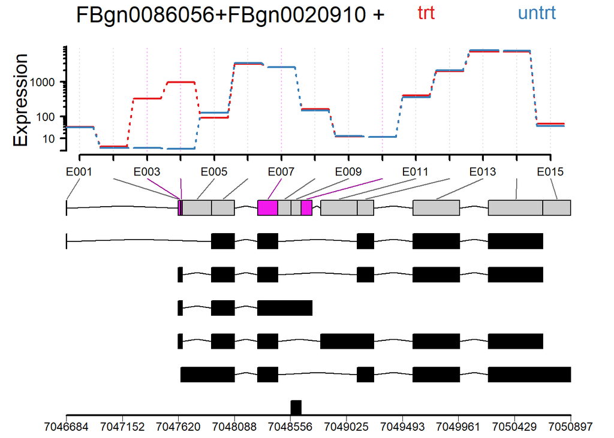

```r
plotDEXSeq(dxr, DEU_gene, fitExpToVar = 'cond', legend=TRUE, displayTranscripts = TRUE, cex.axis=1.2, cex=1.3, lwd=2)
```